# Where Profit Takes Root

Kayle Megginson

2025-04-21

# Presentation Overview

- Predict the profitability of future CravenSpeed products
- Use existing product and sales data to train a machine learning model
- Identify key factors that influence product success
- Keep the model interpretable and only use 10 features
- Evaluate predictions using Root Mean Squared Error (RMSE)

# Data Overview

- **Dataset:** 2,439 products developed by CravenSpeed
- **Target Variable:**  
  `Profit = Revenue (2019–present) – (BOM Cost × Units Sold)`
- **Original Features:**
  - Sales channel percentages (e.g., `pct_Direct Sales`, `src_Amazon FBM`)
  - Product attributes (e.g., `Unit Weight`, `Number of Components`, `Product Type`)
  - Timeline-based fields like `First Order (from sales data)` and monthly sales bins

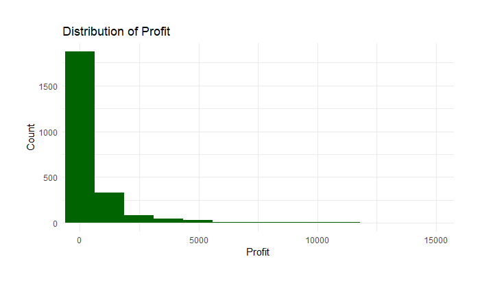

# Feature Engineering Strategy

- Focused on product-level characteristics likely to influence profit
- Prioritized features that captured:
  - **Profitability ratios** (e.g., profit margin, BOM efficiency)
  - **Sales performance** (e.g., log units sold, monthly revenue)
  - **Product complexity** (e.g., weight-to-component ratios)
  - **Use logs for profit modeling**
- Avoid engineering high-cardinality or redundant features
- Perform transformations on numeric and date-based variables

# Final 10 Features

1. **Profit Margin (%)** – Profit as a percent of total revenue
2. **Log Units Sold** – Log-transformed count of units sold
3. **Profit per Unit** – Total profit divided by units sold
4. **Average Monthly Revenue** – Revenue normalized by product age
5. **High Margin Flag** – Binary: 1 if margin > $50
6. **Component Density** – Weight per component (`unit_weight_pounds / number_of_components`)
7. **Revenue-to-Weight Ratio** – Revenue per pound of product
8. **BOM as % of Price** – BOM cost relative to retail price
9. **Product Age** – Years since first recorded sale
10. **Margin ($)** – Retail price minus BOM cost

# Feature Importance

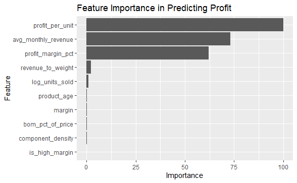

## Model Selection

- Linear Model: RMSE value of 0.43
- The RMSE value is ok, but something under 0.20 would make me feel better

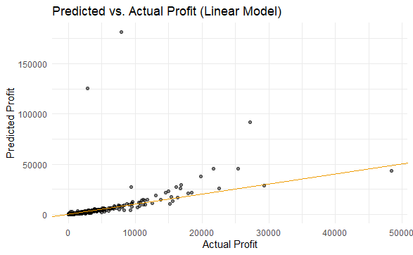

- Pretty close predictions for the smaller profit amounts, but it starts getting less accurate the higher the profit amounts are
- Also has some weird outliers that it predicts

## Introducing: XGBoost (`xgbTree`)

- What is XGBoost?
  - XGBoost stands for **Extreme Gradient Boosting**
  - It’s an ensemble method that builds many decision trees in sequence order, using a gradient descent type approach
  - Strong performance with numeric and engineered features
- Stabilizes variance and improves error distribution
- Each new tree is trained to correct the **errors of the previous trees**
- The model combines these “weak learners” into a powerful prediction engine

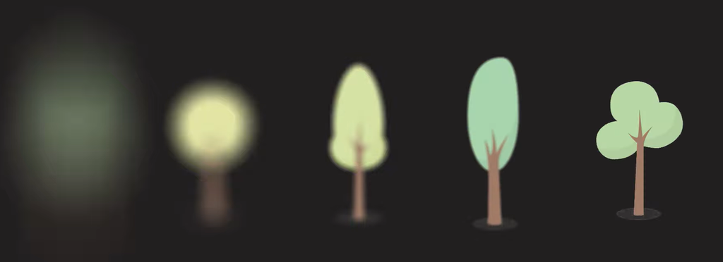

Photo from: https://www.youtube.com/watch?v=TyvYZ26alZs

## Why XGBoost Works Well Here:

- **Profit is nonlinear** — small changes in price or units sold can create large changes in profit
- **Feature interactions matter** — e.g., margin only matters when units sold is high
- **Handles skewed targets** — profit has large outliers and a long right tail
- Automatically learns **thresholds** (e.g., what qualifies as “high margin”)
- Built-in **regularization** avoids overfitting on rare product types or extreme cases
- Works well with the model’s mix of **engineered numeric and binary features**

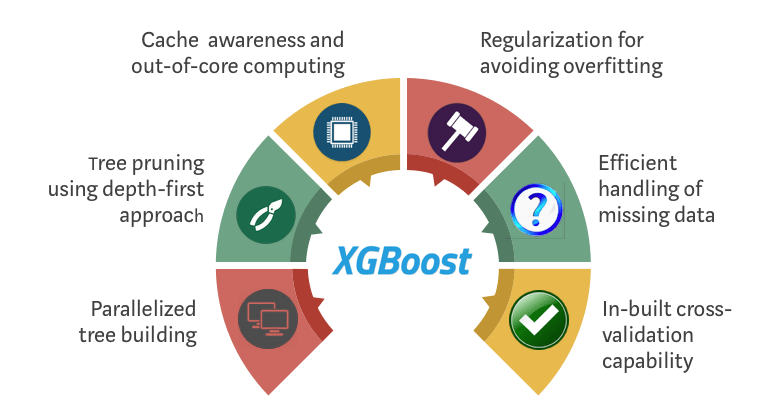

Photo from: https://www.linkedin.com/pulse/xgboost-classifier-algorithm-machine-learning-kavya-kumar/

## Model Performance

- **Evaluation Metric:** Root Mean Squared Error (RMSE)
- RMSE calculated on log-transformed profit

### Final Results:

- **RMSE value: 0.08858**
- Better RMSE value than linear regression model and also fits data better
- Value is under 0.20, so I am pretty confident in its accuracy in predicting future profit
- Lets see how well the model can predict profit

# Predicted vs Actual

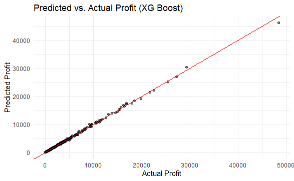

- Most predictions fall close to the regression line
- Most of the data is clustered in the lower profit amounts

# Insights & Takeaways

- Profit prediction is feasible and highly accurate with the right engineered features
- The most influential features were: **Profit per unit**, **average monthly revenue**, and **profit margin %**
- Feature engineering captured nonlinear effects and normalized skewed values
- XGBoost used these features to make a relatively accurate prediction model
- Final model predicts profit with a root mean square error of about 0.09, even across diverse product types

# Thank You

Questions?